# PA1_template

## Libraries:

```r
library(ggplot2)
library(dplyr)
```

## Loading and preprocessing the data

1. Load the data:

```r
temp <- getwd()
download.file("https://d396qusza40orc.cloudfront.net/repdata%2Fdata%2Factivity.zip","repdata_data_activity.zip")
t   <- unz(temp, "repdata_data_activity.zip")
data_activity0 <- read.csv('activity.csv', header=T,na.strings = c("NA"))
```

2. Process/transform the data (if necessary) into a format suitable for your analysis

```r
data_activity0$date <- as.Date(data_activity0$date, format="%Y-%m-%d")
```

## What is mean total number of steps taken per day?

For this part of the assignment, you can ignore the missing values in the dataset.

```r
data_activity <- data_activity0[!is.na(data_activity0$steps),]
```

1. Calculate the total number of steps taken per day

```r
steps_date <- data_activity %>% group_by(date) %>% summarise_each(funs(sum),steps)
```

2. Make a histogram of the total number of steps taken each day

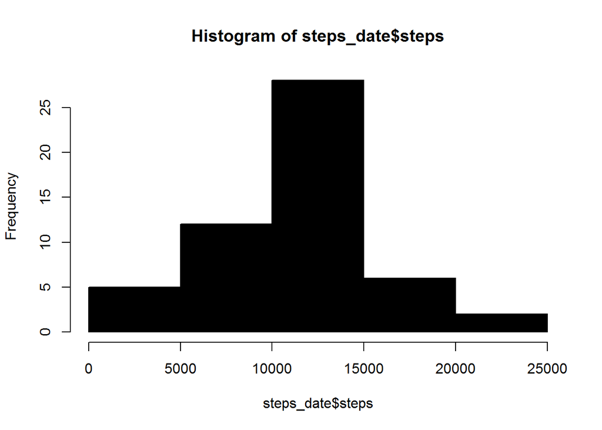

```r
hist(steps_date$steps, col=1)
```

3. Calculate and report the mean and median of the total number of steps taken per day

```r
 data_activity %>% group_by(date) %>% summarise_each(funs(mean,median),steps)
```

```
## Source: local data frame [53 x 3]
##
##          date     mean median
## 1  2012-10-02  0.43750      0
## 2  2012-10-03 39.41667      0
## 3  2012-10-04 42.06944      0
## 4  2012-10-05 46.15972      0
## 5  2012-10-06 53.54167      0
## 6  2012-10-07 38.24653      0
## 7  2012-10-09 44.48264      0
## 8  2012-10-10 34.37500      0
## 9  2012-10-11 35.77778      0
## 10 2012-10-12 60.35417      0
## ..        ...      ...    ...
```

## What is the average daily activity pattern?

1. Make a time series plot (i.e. type = “l”) of the 5-minute interval (x-axis) and the average number of steps taken, averaged across all days (y-axis)

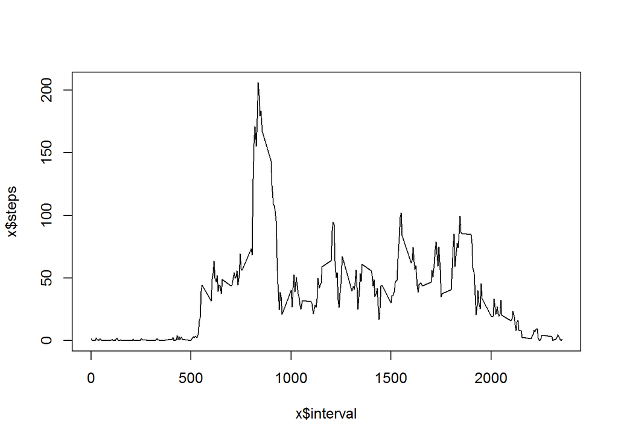

```r
x <- data_activity %>% group_by(interval) %>% summarise_each(funs(mean),steps)
plot(x$interval, x$steps, type='l', col=1)
```

2. Which 5-minute interval, on average across all the days in the dataset, contains the maximum number of steps?

```r
x[x$steps == max(x$steps),]
```

```
## Source: local data frame [1 x 2]
##
##   interval    steps
## 1      835 206.1698
```

## Imputing missing values

1. Calculate and report the total number of missing values in the dataset (i.e. the total number of rows with NAs)

```r
count(data_activity0[is.na(data_activity0$steps),])
```

```
## Source: local data frame [1 x 1]
##
##      n
## 1 2304
```

2. Devise a strategy for filling in all of the missing values in the dataset. The strategy does not need to be sophisticated. For example, you could use the mean/median for that day, or the mean for that 5-minute interval, etc.

In this step I decided to take the mean for each interval and fill the null values with that data

```r
x$round <- round(x$steps, digits = 0)
data_activity0$newvalue <- x[match(data_activity0$interval, x$interval),3]
```

3. Create a new dataset that is equal to the original dataset but with the missing data filled in.

```r
nullvalues <- data_activity0[is.na(data_activity0$steps),]
nullvalues$steps<- NULL
nullvalues <- data.frame( steps = nullvalues$newvalue, date = nullvalues$date, interval = nullvalues$interval)
names(nullvalues)[1]<-paste("steps")
newdata <- data_activity0[!is.na(data_activity0$steps),]
newdata$newvalue <- NULL
newdata <- rbind(newdata,nullvalues)
```

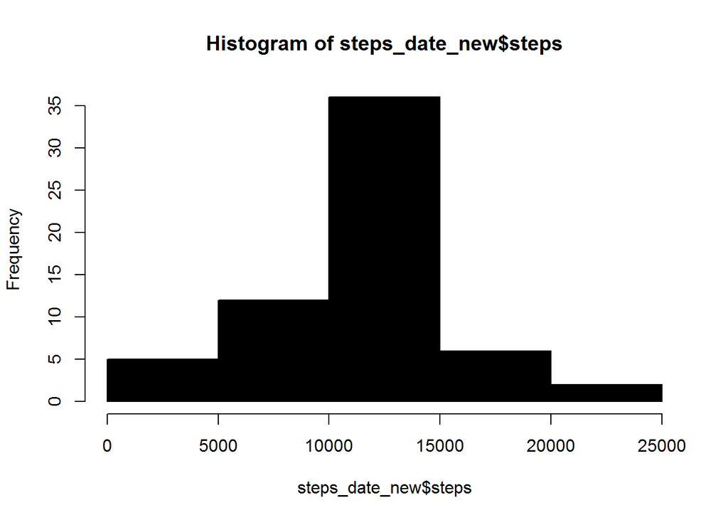

```r
steps_date_new <- newdata %>% group_by(date) %>% summarise_each(funs(sum),steps)
hist(steps_date_new$steps, col=1)
```

```r
newdata %>% group_by(date) %>% summarise_each(funs(mean,median),steps)
```

```
## Source: local data frame [61 x 3]
##
##          date     mean median
## 1  2012-10-01 37.36806   34.5
## 2  2012-10-02  0.43750    0.0
## 3  2012-10-03 39.41667    0.0
## 4  2012-10-04 42.06944    0.0
## 5  2012-10-05 46.15972    0.0
## 6  2012-10-06 53.54167    0.0
## 7  2012-10-07 38.24653    0.0
## 8  2012-10-08 37.36806   34.5
## 9  2012-10-09 44.48264    0.0
## 10 2012-10-10 34.37500    0.0
## ..        ...      ...    ...
```

## Are there differences in activity patterns between weekdays and weekends

For this part the weekdays() function may be of some help here. Use the dataset with the filled-in missing values for this part.

1. Create a new factor variable in the dataset with two levels - “weekday” and “weekend” indicating whether a given date is a weekday or weekend day.

```r
newdata <- newdata %>% mutate( day = as.factor(ifelse( weekdays(newdata$date) == 'Sunday' | weekdays(newdata$date) == 'Saturday' ,'weekend' ,'weekday') ))
```

2. Make a panel plot containing a time series plot (i.e. type = “l”) of the 5-minute interval (x-axis) and the average number of steps taken, averaged across all weekday days or weekend days (y-axis).

[figure not shown]

```r
x <- newdata %>% group_by(interval, day) %>% summarise_each(funs(mean),steps)
qplot(x$interval, x$steps, data=x, geom=c("line"), xlab="Interval",
      ylab="Number of steps", main="") + facet_wrap(~ day, ncol=1)
```